# NYC Shooting assignment

# Shooting Incident Data Report

## 9/17/2024

## Introduction

NYPD Shooting Incident DATASET is extracted from NYC Gov website, Data provided by Police Department (NYPD). The list is a breakdown of every shooting incident that occurred in NYC going back to 2006 through the end of the 2022.

DATASET information from the Data owner (NYC Open Data): Each record represents a shooting incident in NYC and includes information about the event, the location and time of occurrence. In addition, information related to suspect and victim demographics is also included. This data can be used by the public to explore the nature of shooting/criminal activity.

Three steps in this assignment: Import, clean Data and analyze.

### Import

```r
#Import the data from the server
url_in<-"https://data.cityofnewyork.us/api/views/833y-fsy8/rows.csv?accessType=DOWNLOAD"
#Read the file
cases<-read_csv(url_in)
```

### Data Cleaning

```r
spec(cases)
cases<-cases %>%
select(-c(LOC_CLASSFCTN_DESC,LOC_OF_OCCUR_DESC,JURISDICTION_CODE,LOCATION_DESC,OCCUR_TIME)) %>%
rename(DATE="OCCUR_DATE",Murder="STATISTICAL_MURDER_FLAG")
#Format the Date
cases$DATE <- as.Date(cases$DATE, format = "%m/%d/%Y")
#Check for NA values
cases %>%
  summarize(across(everything(), ~ sum(is.na(.))))
```

```
## # A tibble: 1 × 16
##   INCIDENT_KEY  DATE  BORO PRECINCT Murder PERP_AGE_GROUP PERP_SEX PERP_RACE
##          <int> <int> <int>    <int>  <int>          <int>    <int>     <int>
## 1            0     0     0        0      0           9344     9310      9310
## # ℹ 8 more variables: VIC_AGE_GROUP <int>, VIC_SEX <int>, VIC_RACE <int>,
## #   X_COORD_CD <int>, Y_COORD_CD <int>, Latitude <int>, Longitude <int>,
## #   Lon_Lat <int>
```

```r
#Remove NA values from Latitude, Longitude and Lon_Lat, only few values
cases<-cases %>%
filter(!is.na(Latitude),!is.na(Longitude),!is.na(Lon_Lat))  %>%
#Replace NA and (null) by UNKNOWN
mutate(across(c(PERP_AGE_GROUP, PERP_SEX, PERP_RACE), ~ replace_na(., "UNKNOWN")))  %>%
mutate(across(where(is.character),~ ifelse(. == "(null)", "UNKNOWN", .)))
```

### Visualization per BORO

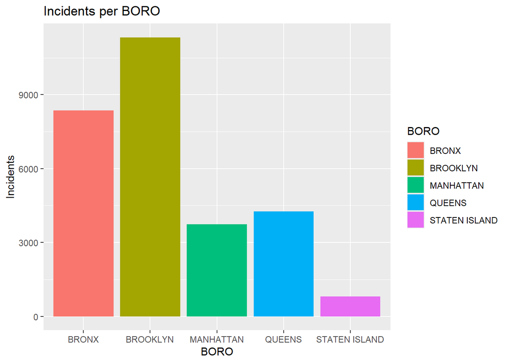

```r
#Data grouped by BORO, it includes the total number of incidents
boro_cases <- cases %>% group_by(BORO) %>%
summarize(Incidents = n())
ggplot(boro_cases, aes(x=BORO, y=Incidents, fill=BORO)) +
geom_bar(stat="identity") +
xlab("BORO") + ylab("Incidents") +
ggtitle("Incidents per BORO")
```

### Visualization per Victim Race per BORO

```r
casestb<-cases %>%
filter(VIC_RACE!="UNKNOWN") %>%
group_by(BORO,VIC_RACE) %>%
summarize(TOT_COUNT = n())
```

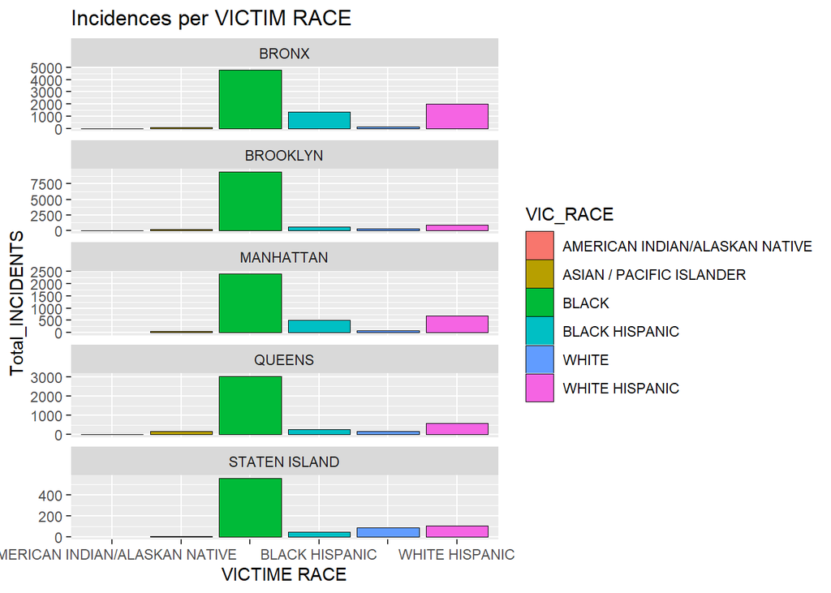

```r
ggplot(casestb,aes(x = VIC_RACE, y = TOT_COUNT,fill=VIC_RACE)) +
geom_bar(stat = "identity", color = "black", size = 0.1) +
xlab("VICTIME RACE") + ylab("Total_INCIDENTS") +
scale_x_discrete(guide = guide_axis(check.overlap = TRUE)) +
ggtitle("Incidences per VICTIM RACE") +
facet_wrap(~BORO, scales="free_y",ncol=1)
```

# Model Analysis: Correlation rate versus poverty % per BORO

```r
casesm<-cases %>%
#Poverty % and Population numbers per BORO were collected from Wikipedia
#Add a column with population size
#filter(Murder=="TRUE") %>%
group_by(BORO)  %>%
summarize(Incidents = n()) %>%
mutate(Population = case_when(
BORO == "BROOKLYN" ~ (2465326),
BORO == "BRONX" ~ (1332650),
BORO == "MANHATTAN" ~ (1537195),
BORO == "QUEENS" ~ (2229379),
BORO == "STATEN ISLAND" ~ (495747),
    ),rate=Incidents/Population,Poverty_Per_Cent=case_when(
BORO == "BROOKLYN" ~ (19.8),
BORO == "BRONX" ~ (27.6),
BORO == "MANHATTAN" ~ (17.2),
BORO == "QUEENS" ~ (13.1),
BORO == "STATEN ISLAND" ~ (11.2),
    ))
casesm
```

```
## # A tibble: 5 × 5
##   BORO          Incidents Population    rate Poverty_Per_Cent
##   <chr>             <int>      <dbl>   <dbl>            <dbl>
## 1 BRONX              8363    1332650 0.00628             27.6
## 2 BROOKLYN          11331    2465326 0.00460             19.8
## 3 MANHATTAN          3746    1537195 0.00244             17.2
## 4 QUEENS             4263    2229379 0.00191             13.1
## 5 STATEN ISLAND       800     495747 0.00161             11.2
```

```r
#Model Rate versus Poverty_Per_Cent
mod <- lm(rate ~ Poverty_Per_Cent, data = casesm)
summary(mod)
```

```
##
## Call:
## lm(formula = rate ~ Poverty_Per_Cent, data = casesm)
##
## Residuals:
##          1          2          3          4          5
## -4.417e-05  6.219e-04 -7.556e-04 -4.748e-05  2.254e-04
##
## Coefficients:
##                    Estimate Std. Error t value Pr(>|t|)
## (Intercept)      -1.979e-03  8.427e-04  -2.349  0.10041
## Poverty_Per_Cent  3.007e-04  4.509e-05   6.669  0.00687 **
## ---
## Signif. codes:  0 '***' 0.001 '**' 0.01 '*' 0.05 '.' 0.1 ' ' 1
##
## Residual standard error: 0.000581 on 3 degrees of freedom
## Multiple R-squared:  0.9368, Adjusted R-squared:  0.9157
## F-statistic: 44.48 on 1 and 3 DF,  p-value: 0.006874
```

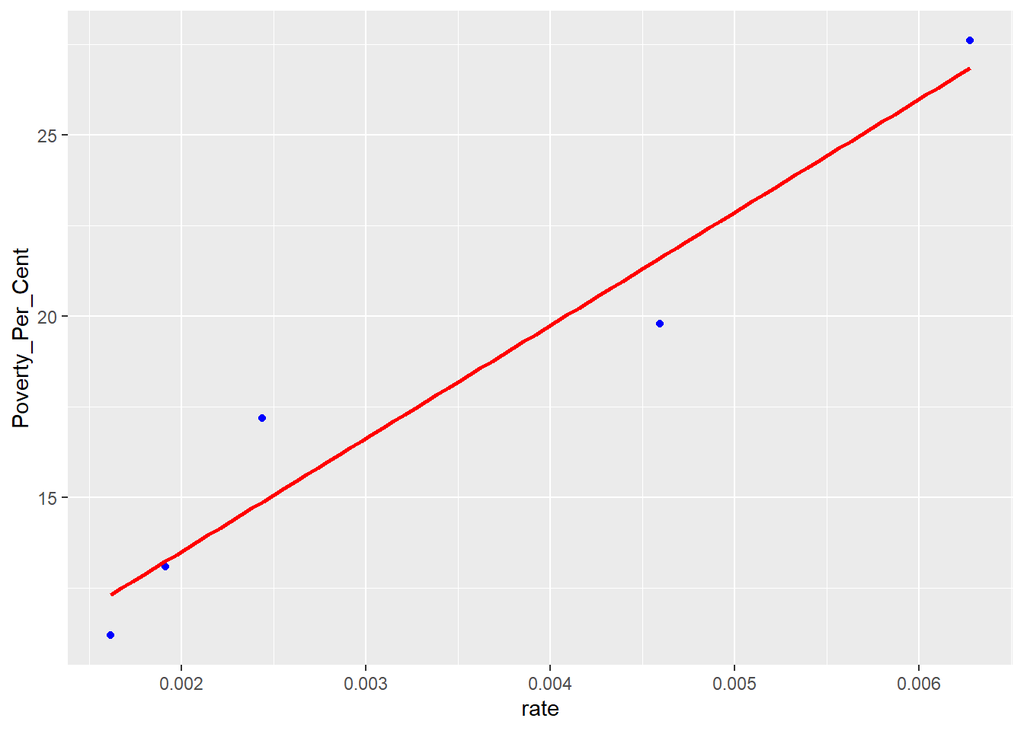

```r
ggplot(data=casesm, aes(rate,Poverty_Per_Cent)) +
  geom_point(color="blue") +
  geom_smooth(method = "lm", se = FALSE,color="red")
```

## Conclusion

I followed these steps:

1- Importing Data

2- Cleaning data including replacing NA and (Null) per Unknown and formatting date

3- First visualization per BORO: BROOKLYN number is the highest

4- Second visualization includes number of incidence per Victim Race: Black Victim Race numbers are the highest

5- Adding the incident rate and Poverty_Per_Cent per BORO

6- Modeling rate versus Poverty_Per_Cent

Looking at the second plot, I could see clearly that “incident total numbers” for black population were the highest in all BORO. However, the model rate versus Poverty Per Cent shows a linear correlation. There are two bias that I identified:

1- Certain values are UNKOWN or Null so I had to be sure that it did not add any bias to the analysis.

2- The number of incidents per “Victim Race” is high in all boroughs but I had to include “Population number” and “Poverty Per Cent” columns to make it more relevant and avoid any bias.

Finally, in my opinion and it was confirmed in this analysis, the poverty is an important factor and it needs to be tracked in this DATASET.